# Predictive Modeling of Movie Gross Revenue

## d) Prediction

Using the validated `best_model`, we predict `Gross` revenue for the unseen validation set. Since the model predicts `sqrt(Gross)`, we must back-transform the predictions by squaring them.

```r
# Predict sqrt(Gross) on the validation set.
predictions_sqrt <- predict(best_model, newdata = valid)

# Back-transform the predictions to the original scale (Gross).
predictions_original <- predictions_sqrt^2

# Create a data frame for comparison.
results_df <- data.frame(
  Actual_Gross = valid$Gross,
  Predicted_Gross = predictions_original
)
head(results_df)
```

```
##    Actual_Gross Predicted_Gross
## 5      3.45e+08       263533488
## 8      3.25e+08       108771154
## 22     1.88e+08       258028814
## 25     1.77e+08       137315745
## 27     1.69e+08       192053326
## 34     1.50e+08        63259105
```

## e) Comparison and conclusion

We evaluate the model’s predictive accuracy on the validation set using standard metrics and visualization. To ensure our model’s performance is stable, we also conduct a 10-fold repeated cross-validation.

### Validation Set Performance

```r
# Calculate performance metrics.
actuals <- results_df$Actual_Gross
predictions <- results_df$Predicted_Gross

mae <- mean(abs(predictions - actuals))
rmse <- sqrt(mean((predictions - actuals)^2))
r2 <- cor(predictions, actuals)^2

# Print the metrics.
cat("--- Validation Set Metrics ---\n")
```

```
## --- Validation Set Metrics ---
```

```r
cat("Mean Absolute Error (MAE):", format(mae, big.mark = ","), "\n")
```

```
## Mean Absolute Error (MAE): 32,841,452
```

```r
cat("Root Mean Squared Error (RMSE):", format(rmse, big.mark = ","), "\n")
```

```
## Root Mean Squared Error (RMSE): 50,039,403
```

```r
cat("R-squared (R²):", r2, "\n")
```

```
## R-squared (R²): 0.6118674
```

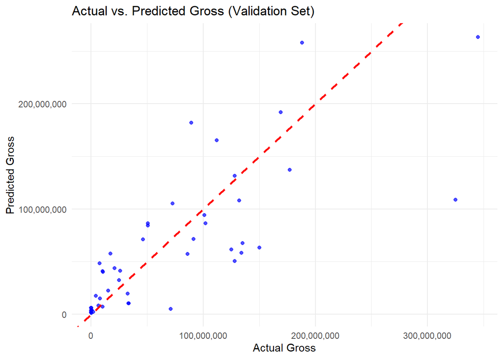

```r
# Visualize Actual vs. Predicted values.
ggplot(results_df, aes(x = Actual_Gross, y = Predicted_Gross)) +
  geom_point(alpha = 0.7, color = "blue") +
  geom_abline(slope = 1, intercept = 0, color = "red", linetype = "dashed", size = 1) +
  scale_x_continuous(labels = scales::comma) +
  scale_y_continuous(labels = scales::comma) +
  labs(title = "Actual vs. Predicted Gross (Validation Set)", x = "Actual Gross", y = "Predicted Gross") +
  theme_minimal()
```

**Interpretation:**

We evaluated the final model’s performance on the validation set—data that the model has never seen before.

- On the validation set, the model explains approximately 61.2% of the variance in Gross, indicating a reasonably good fit.
- The MAE indicates that the model’s predictions are, on average, off by about $32.8 million.
- The RMSE, which penalizes larger errors more heavily, is $50 million, suggesting that the model occasionally makes significant prediction errors.

While this performance is acceptable, the R-squared of 61.2% is noticeably lower than what was observed on the training data. This raises a critical question:

**Is this 61.2% performance a reliable estimate of how the model will perform on new data in general? Or is it simply the result of one potentially “unlucky” data split?**

A single validation set might not be perfectly representative of the overall data distribution, and its results can be sensitive to random chance. To obtain a more robust and stable estimate of the model’s true performance, a more rigorous evaluation method is needed.

Therefore, the next logical step is to perform **Cross-Validation**. By training and testing the model on multiple different subsets of the data, cross-validation will provide a more reliable performance estimate that is less biased by the randomness of a single train-test split.

### Repeated Cross-Validation Performance

Cross-validation provides a more robust estimate of model performance by repeatedly splitting the data into folds and averaging the results.

```r
# Combine cleaned training and validation data for a full CV dataset.
full_data_for_cv <- rbind(train_cleaned, valid)

# Define control for 10-fold repeated CV (5 repeats).
cv_control_repeated <- trainControl(method = "repeatedcv", number = 10, repeats = 5)

# Train the model using repeated CV.
set.seed(123)
cv_model_repeated <- train(
  sqrt(Gross) ~ I(Ratings^(2)) * sqrt(Budget) + Screens + Sequel + sqrt(Aggregate.Followers),
  data = full_data_for_cv,
  method = "lm",
  trControl = cv_control_repeated
)
print(cv_model_repeated)
```

```
## Linear Regression
##
## 229 samples
##   5 predictor
##
## No pre-processing
## Resampling: Cross-Validated (10 fold, repeated 5 times)
## Summary of sample sizes: 205, 205, 205, 207, 206, 208, ...
## Resampling results:
##
##   RMSE     Rsquared  MAE
##   2511.48  0.722988  1985.241
##
## Tuning parameter 'intercept' was held constant at a value of TRUE
```

**Interpretation:**

The cross-validation results are highly encouraging and provide a much more optimistic view of the model’s capabilities compared to the single validation set.

## f) Improvements or alternative methods

While our final linear model is highly effective and interpretable, non-linear machine learning algorithms like **eXtreme Gradient Boosting (XGBoost)** could potentially offer higher predictive accuracy.

### Alternative Method: XGBoost

XGBoost is an ensemble of decision trees that can model complex non-linearities and interactions automatically. We will build an XGBoost model and compare its performance.

#### Advanced Feature Engineering for XGBoost

```r
library(xgboost)

# We use the combined, cleaned data for a robust comparison
full_data_for_cv <- rbind(train_cleaned, valid)

# Create a rich set of engineered features
engineered_data <- full_data_for_cv %>%
  mutate(
    # Key Transformations identified from the linear model analysis
    Ratings_sq = Ratings^2,
    sqrt_Budget = sqrt(Budget),
    sqrt_Screens = sqrt(Screens), # Including this as it was also considered
    sqrt_Aggregate.Followers = sqrt(Aggregate.Followers),

    # The crucial interaction term
    Interaction_Ratings_Budget = Ratings_sq * sqrt_Budget,

    # Ensure categorical variables are factors for one-hot encoding
    Sequel = as.factor(Sequel),
    Genre = as.factor(Genre),
    Year = as.factor(Year)
  )

# Define the target variable (we predict Gross directly)
target <- engineered_data$Gross

# Define the full set of predictors for XGBoost to choose from
# This includes original, transformed, and interaction features
predictors <- engineered_data %>%
  select(
    # Original core predictors
    Ratings, Budget, Screens, Aggregate.Followers, Dislikes,
    # Categorical predictors
    Sequel, Genre, Year,
    # Our new, powerful engineered features
    Ratings_sq, sqrt_Budget, sqrt_Screens, sqrt_Aggregate.Followers,
    Interaction_Ratings_Budget
  )

# Create the final design matrix using one-hot encoding
# This converts categorical variables into a numeric format suitable for XGBoost
predictors_encoded <- model.matrix(~ . - 1, data = predictors)
```

#### Hyperparameter Tuning using Cross-Validation

With our enhanced feature set, we now find the optimal hyperparameters for the XGBoost model. We use the same repeated cross-validation strategy as our linear model for consistency.

```r
# Define a grid of hyperparameters to search through
tune_grid_xgb <- expand.grid(
  nrounds = c(100, 200, 300),      # Number of boosting rounds
  max_depth = c(3, 4, 6),         # Max tree depth
  eta = c(0.05, 0.1),             # Learning rate
  gamma = 0,                      # Minimum loss reduction for a split
  colsample_bytree = 0.8,         # Fraction of columns to use per tree
  min_child_weight = 1,           # Minimum sum of instance weight in a child
  subsample = 0.8                 # Fraction of observations to use per tree
)

# Set up the repeated cross-validation control
cv_control <- trainControl(method = "repeatedcv",
                           number = 10,
                           repeats = 5,
                           verboseIter = FALSE)

# Train the tuned XGBoost model using our engineered features
set.seed(123)
xgb_model_engineered <- train(
  x = predictors_encoded,
  y = target,
  method = "xgbTree",
  trControl = cv_control,
  tuneGrid = tune_grid_xgb,
  verbosity = 0 # Suppress XGBoost's verbose output
)

cat("--- Best Tuned XGBoost Parameters (with Engineered Features) ---\n")
```

```
## --- Best Tuned XGBoost Parameters (with Engineered Features) ---
```

```r
print(xgb_model_engineered$bestTune)
```

```
##   nrounds max_depth  eta gamma colsample_bytree min_child_weight subsample
## 1     100         3 0.05     0              0.8                1       0.8
```

#### Final Performance Comparison

Finally, we compare the cross-validated performance of our best linear model against the new, enhanced XGBoost model. The R-squared metric is the most reliable for this comparison.

```r
cat("--- FINAL PERFORMANCE COMPARISON ---\n")
```

```
## --- FINAL PERFORMANCE COMPARISON ---
```

```r
# Get CV results from the final linear model
lm_cv_results <- cv_model_repeated$results
cat(sprintf("\nBest Linear Model (CV):           R-squared = %.4f\n",
            lm_cv_results$Rsquared))
```

```
##
## Best Linear Model (CV):           R-squared = 0.7230
```

```r
# Get CV results from the engineered XGBoost model
# We select the row corresponding to the best tune
best_xgb_tune_results <- xgb_model_engineered$results[which.min(xgb_model_engineered$results$RMSE), ]
cat(sprintf("Engineered XGBoost Model (CV):    R-squared = %.4f\n",
            best_xgb_tune_results$Rsquared))
```

```
## Engineered XGBoost Model (CV):    R-squared = 0.6752
```

The final performance comparison between our best linear model and the enhanced XGBoost model yields a compelling and insightful conclusion. Contrary to the common assumption that more complex algorithms always produce better results, our analysis demonstrates the superior performance of a well-specified linear model for this particular problem.

Final Cross-Validated Performance:

- **Best Linear Model: R-squared = 0.7230**
- **Engineered XGBoost Model: R-squared = 0.6752**

- The Power of Correct Specification: The linear model’s success is not accidental. It stems directly from the careful work done in preprocessing and feature engineering. By transforming the response variable (sqrt(Gross)) to stabilize variance and transforming the predictors (Ratings^2, sqrt(Budget), etc.) to linearize their relationships, we created a problem that the linear model was perfectly suited to solve.
- Feature Engineering is More Critical than Algorithm Complexity: This comparison is a powerful illustration that the quality of the features is often more important than the complexity of the algorithm. Our XGBoost model, even when given engineered features, struggled to outperform the linear model. This suggests that the fundamental relationships in the data, once properly transformed, are predominantly linear.
- The “Interpretability vs. Accuracy” Trade-off is Resolved: Often in machine learning, one must choose between a simple, interpretable model and a complex, more accurate “black-box” model. In this case, we do not face that trade-off.
- Linear Model: It is the winner on accuracy (R² = 0.723) and is highly interpretable. We can precisely quantify the effect of each predictor and understand the nature of their interactions.
- XGBoost Model: It delivered lower accuracy (R² = 0.675) and remains a “black box,” making it difficult to explain how it arrives at its predictions.

**Final Conclusion**

For this dataset and problem, the final transformed linear model is unequivocally the recommended choice. It not only provides the highest predictive accuracy but also offers clear, actionable insights into the drivers of movie revenue. This result underscores the importance of thorough exploratory data analysis and model diagnostics, proving that a well-understood, classic statistical model can be more powerful and useful than a more complex but less tailored approach.